# 2018 Ford GoBike Data Exploration and Visualization

## by Ahmad Mohsen Hashhash

## Date : 29/12/2020

## Preliminary Wrangling

> Ford GoBike now known as "Bay Wheels" is a regional public bicycle sharing system in California's San Francisco Bay Area.Bay Wheels is the first regional and large-scale bicycle sharing system deployed in California and on the West Coast of the United States. It was established as Bay Area Bike Share in August 2013. As of January 2018, the Bay Wheels system had over 2,600 bicycles in 262 stations across San Francisco, East Bay and San Jose. In this dataset, we have the data for the bikes system for the month February 2018 and I will add the remaining months for the same year to make a whole year dataset that we should start doing exploratory analysis for.

## Univariate Exploration

> In this section, investigate distributions of individual variables. If you see unusual points or outliers, take a deeper look to clean things up and prepare yourself to look at relationships between variables.

### Monthly Bike Trips Count

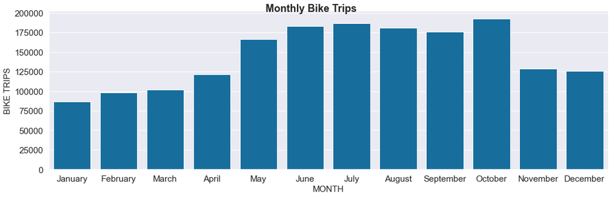

```python
#Distribution of number of bike trips over months
clr = sb.color_palette('colorblind')[0];
trips_month = sb.catplot(data = wrangled_df, x='start_month', kind='count', color = clr, aspect = 3);
plt.xlabel("MONTH",  fontsize = 15);
plt.ylabel("BIKE TRIPS", fontsize = 15);
trips_month.fig.suptitle('Monthly Bike Trips', fontsize=18, fontweight='bold');
```

As we can see, highest number of trips occurs in summer months with a peak in october then reachs it lowest points in winter and start increasing during spring

### Hourly Bike Trips Count

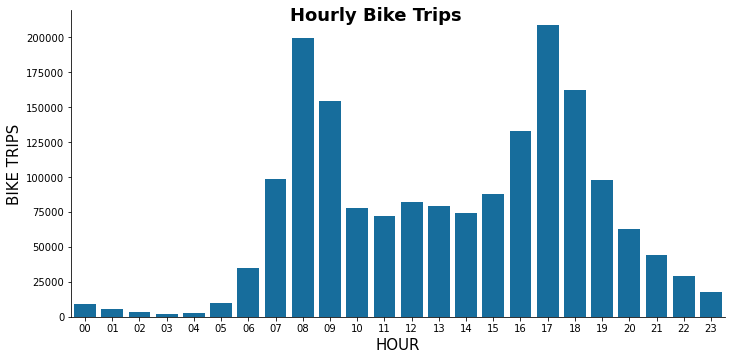

```python
#most popular hour of day for bike trips
clr = sb.color_palette('colorblind')[0]
trips_hour = sb.catplot(data = wrangled_df, x='start_hourofday', kind='count', color = clr, aspect = 2);
plt.xlabel("HOUR",  fontsize = 15);
plt.ylabel("BIKE TRIPS", fontsize = 15);
trips_hour.fig.suptitle('Hourly Bike Trips', fontsize=18, fontweight='bold');
```

Pretty accurate!!, from the plot above we can notice that the hours where peaks occur are while going to work and return from it with some fluctuations in between these hours and decreasing in the evening

### Trips Count for Members Age

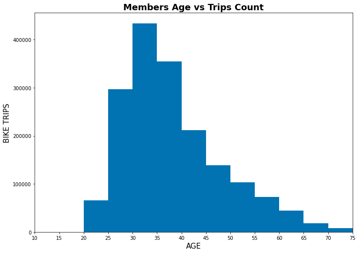

```python
#most popular age of members
plt.figure(figsize=[ 11.69, 8.27]);
bins = np.arange(0, wrangled_df['member_age'].max()+5, 5)
clr = sb.color_palette('colorblind')[0]
plt.hist(data=wrangled_df, x = 'member_age', bins = bins, color = clr)
plt.xticks(bins, bins)
plt.xlabel('AGE', fontsize = 15);
plt.ylabel('BIKE TRIPS', fontsize = 15);
plt.title('Members Age vs Trips Count', fontsize=18, fontweight='bold' );
plt.xlim([10, 75]);
```

The most popular age of our customers and members is from 25 to 40 years old and as the age increases the bike trips get lower which means usage is less

### Discuss the distribution(s) of your variable(s) of interest. Were there any unusual points? Did you need to perform any transformations?

As we saw from the plots related to trips count distribution over time (Hour-Day-Month) we figured out that the peak of trips count is between (6-9) and (17-19) and during all work day are in high demand and low demand in weekends also we noticed that the number of trips increases the most during the year starting from spring when it reaches its peak in october then goes down again in winter

Also the member age who do trips the most varies between 25 to 40 years old

### Of the features you investigated, were there any unusual distributions? Did you perform any operations on the data to tidy, adjust, or change the form of the data? If so, why did you do this?

Also I had to extract the member age by subtracting the birth year from the current year to get the direct age which will be more benficial in the analysis process

### Relation between Trip Duration and Member Gender

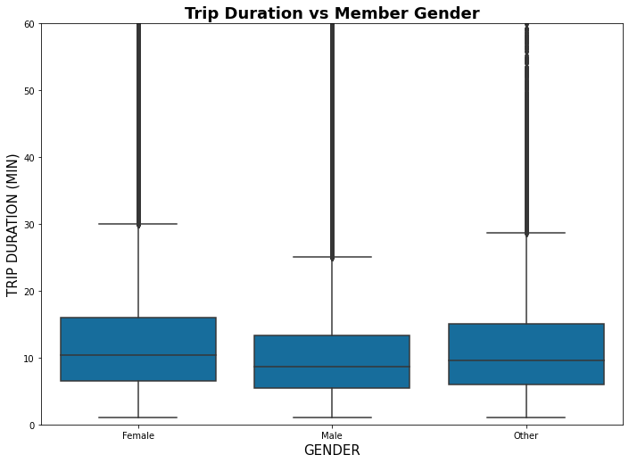

```python
#drawing a box plot for relation between trip duration and member age
plt.figure(figsize=[ 11.69, 8.27]);
clr = sb.color_palette('colorblind')[0]
sb.boxplot(data=wrangled_df, x='member_gender', y='trip_duration', color=clr);
plt.xlabel('GENDER',  fontsize=15);
plt.ylabel('TRIP DURATION (MIN)', fontsize=15);
plt.title('Trip Duration vs Member Gender',  fontsize=18, fontweight='bold')
plt.ylim([0, 60]);
```

Seems like females are having a longer duration trips in comparison with males and other genders, that was noticed by the higher median and longer IQR for females

### Relation between Member Age and Trip Duration

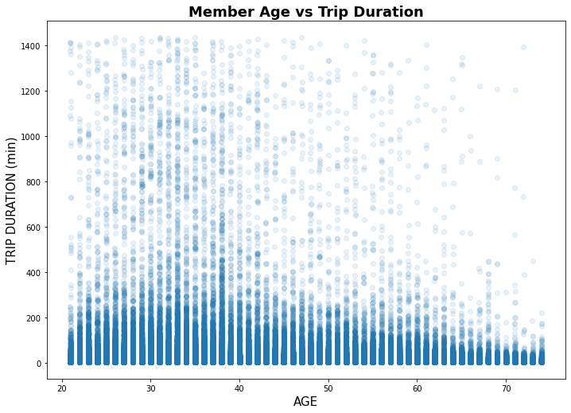

```python
#Scatter Plot between the Member age and Trip duration
plt.figure(figsize=[ 11.69, 8.27]);
sb.regplot(data = wrangled_df, x = 'member_age', y = 'trip_duration', x_jitter=0.04, scatter_kws={'alpha':1/10}, fit_reg=False)
plt.xlabel('AGE', fontsize=15)
plt.ylabel('TRIP DURATION (min)', fontsize=15);
plt.title('Member Age vs Trip Duration',  fontsize=18, fontweight='bold');
```

### User Type trips count during weekdays

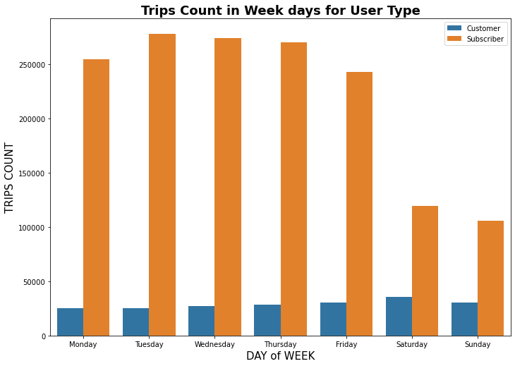

```python
#clustered bar chart for relation between user type and start day of week
plt.figure(figsize=[ 11.69, 8.27]);
days_order = ['Monday', 'Tuesday', 'Wednesday', 'Thursday', 'Friday', 'Saturday', 'Sunday']
sb.countplot(data=wrangled_df, x='start_dayofweek', hue='user_type', order = days_order);
plt.xlabel('DAY of WEEK',  fontsize = 15);
plt.ylabel('TRIPS COUNT',  fontsize = 15);
plt.legend(['Customer', 'Subscriber'])
plt.title('Trips Count in Week days for User Type',  fontsize=18, fontweight='bold');
```

Bike usage between Customers and Subscriber during week is huge, while we notice an increment in customers bike usage during weekends than weekdays which indicates that they use the bikes for wandering around the city or for fun while subscriber tend to use it during weekdays more

### Relation between Trip Duration and User type

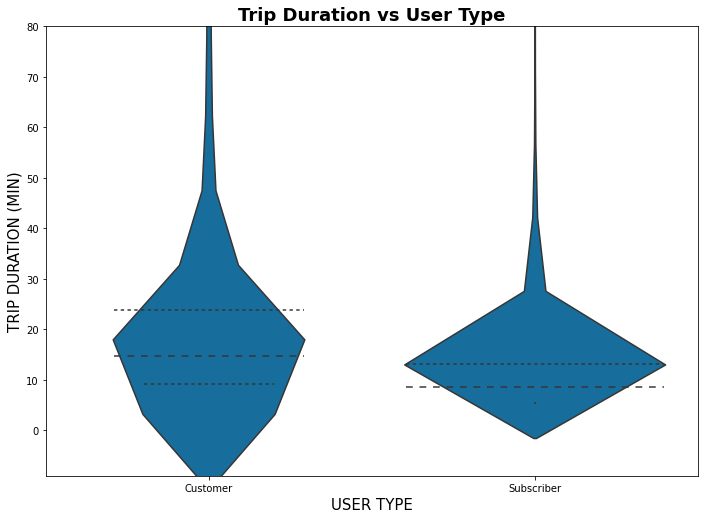

```python
#drawing a violin plot for relation between trip duration and user type
plt.figure(figsize=[ 11.69, 8.27]);
sb.violinplot(data=wrangled_df, x='user_type', y='trip_duration', color=clr, inner = 'quartile');
plt.xlabel('USER TYPE',  fontsize=15);
plt.ylabel('TRIP DURATION (MIN)',  fontsize=15);
plt.title('Trip Duration vs User Type',  fontsize=18, fontweight='bold')
plt.ylim([-9, 80]);
```

Trip duration plot for subscribers is so flat around 10 minutes trips which might indicate that most of the subscribers take the bike for a specific errand while it's narrower for Customers which indicates that they rent the bike for longer durations

### Talk about some of the relationships you observed in this part of the investigation. How did the feature(s) of interest vary with other features in the dataset?

> Females are having longer trip duration than males and other genders. There is no difference about trip distance between genders There is an obvious negative correlation between trip distance and member age Subscribers use bikes in weekdays more than weekends while the opposite happens with customers Subscribers trip durations are kinda fixed around 10-20 minutes while customers tend to use it more up to even 35 minutes Younger members tend to have longer distance trips in comparison with elder members

### Did you observe any interesting relationships between the other features (not the main feature(s) of interest)?

> The relationship that customers use the bikes in weekends more than weekdays, also that females usually take longer trips than other genders

### Trip Duration during weekdays between different member genders

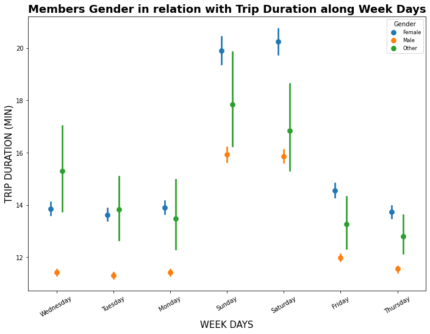

```python
#point plot for variation of trip duration during week between different member genders
plt.figure(figsize=[ 11.69, 8.27]);
sb.pointplot(data=wrangled_df, x='start_dayofweek', y='trip_duration', hue='member_gender', dodge = 0.2, linestyles="");
plt.xlabel('WEEK DAYS',  fontsize=15);
plt.legend(title="Gender", fontsize='small')
plt.xticks(rotation = 30)
plt.ylabel('TRIP DURATION (MIN)',  fontsize=15);
plt.title('Members Gender in relation with Trip Duration along Week Days',  fontsize=18, fontweight='bold');
```

As we can see, males usually having shorter trips duration than females and ther gender all weekdays, while other genders having the longer trips duration on Tuesday and Wednesday and for the remaining days there is female domination related to trip duration along week

### Faceting of Member Gender and Age vs Trip Distance

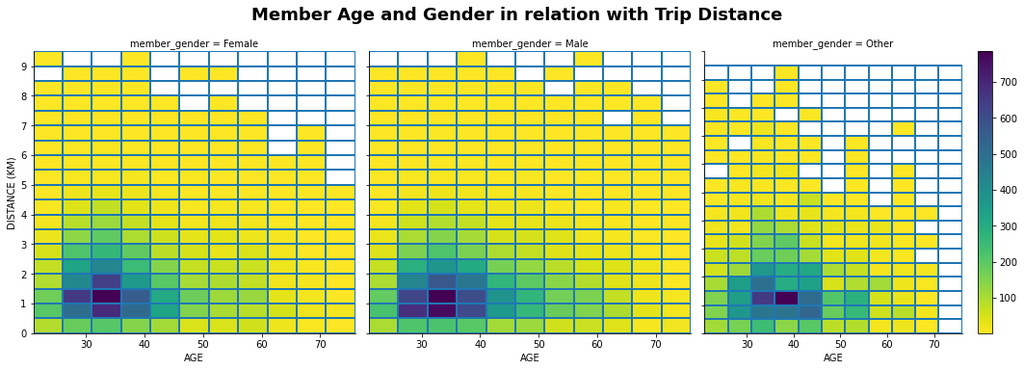

```python
#faceting of member gender and age vs trip distance
xbin = np.arange(wrangled_df['member_age'].min(), wrangled_df['member_age'].max()+5, 5)
ybin = np.arange(0, 10, 0.5)
# #taking a sample from the main df
df_temp = wrangled_df.sample(800000, random_state=42)
g = sb.FacetGrid(data = df_temp, col = 'member_gender',height=5)
g.map(plt.hist2d, 'member_age','dist',cmin=0.5,cmap = 'viridis_r',bins=[xbin, ybin]);
plt.colorbar();
g.set_axis_labels('AGE', 'DISTANCE (KM)')
plt.yticks([0, 1, 2, 3, 4, 5, 6, 7, 8, 9, 10]);
g.fig.suptitle('Member Age and Gender in relation with Trip Distance', fontsize=18, fontweight='bold', y =1.06);
```

Seems like males have a wider age variance with trips distances between 0.5 - 1.5 kms, while other genders users are of ages between 35-40 year old with stable 1 - 1.5 kms trips

### Were there any interesting or surprising interactions between features?

> The surprising interaction that really made me so interested is that females usually having longer trip duration than other genders